# Reviewing ICA method

This is the comment:

*3. I would also like the authors to comment on the possibility of circular inference in the following procedure they applied: adding the mean effect of inattention/hyperactivity symptoms to the connectivity matrices, performing ICASSO on them and then applying the stable components on the data to determine whether those components are associated with the severity of the symptoms.*

We will have to address the main theoretical comment later. But in terms of additional analysis, we can ask the following:

*Does ICASSO favor components associated with SX?*

Before we go ahead, let’s export just the IQs from MATLAB into a CSV:

```
load('/data/NCR_SBRB/ica_results_enrichedNoDummies1K.mat')
dlmwrite('~/tmp/fmri_iqs.csv,iq,',')
```

We can run the inattention and HI regressions for all ICs, and sort them based on IQ.

```r
fmri_iqs = read.csv('~/data/fmri/fmri_iqs.csv', header = F)[,1]
library(RcppCNPy)
fmat <- npyLoad('/Users/sudregp/data/sripada/fmri/exp_scores_enrichedNoDummies1K.npy')
subjs = read.table('~/data/fmri/joel_all_147.txt')
exp_scores = cbind(subjs, fmat)
gf = read.csv('~/data/fmri/gf.csv')
df = merge(gf, exp_scores, by.x='maskid', by.y='V1')
df = df[df$used==1,]
adhdOnly = df$group!='NV'
pvals_inatt = sapply(df[adhdOnly, 14:ncol(df)], function(d) cor.test(d, df[adhdOnly,]$inatt, method='spearman', exact=F)$p.value)
pvals_hi = sapply(df[adhdOnly, 14:ncol(df)], function(d) cor.test(d, df[adhdOnly,]$hi, method='spearman', exact=F)$p.value)
```

Now we make the fMRI plot:

```r
myorder = sort(fmri_iqs, index.return=T, decreasing = T)
par(mfrow=(c(1, 2)))
plot(fmri_iqs[myorder$ix], pvals_inatt[myorder$ix], xlab='Stability', ylab='P-value', main='Inattention')
abline(h=.05, lty=3)
```

```r
abline(v=.85, lty=3)
plot(fmri_iqs[myorder$ix], pvals_hi[myorder$ix], xlab='Stability', ylab='P-value', main='HI')
```

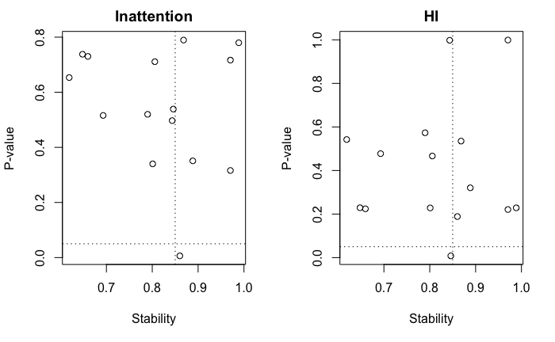

```r
abline(h=.05, lty=3)
abline(v=.85, lty=3)
```

```r
cor.test(1-pvals_inatt, fmri_iqs, method='spearman')
```

```
    Spearman's rank correlation rho

data:  1 - pvals_inatt and fmri_iqs
S = 526, p-value = 0.8324
alternative hypothesis: true rho is not equal to 0
sample estimates:
       rho
0.06071429
```

```r
cor.test(1-pvals_hi, fmri_iqs, method='spearman')
```

```
    Spearman's rank correlation rho

data:  1 - pvals_hi and fmri_iqs
S = 482, p-value = 0.6206
alternative hypothesis: true rho is not equal to 0
sample estimates:
      rho
0.1392857
```

So, there’s clearly no relationship between symptom count and how stable the IC actually is. Let’s try it in MEG:

```r
bands = c('1-4', '4-8', '8-13', '13-30', '30-55', '65-100')
meg_iqs = c()
fmat = c()
for (b in bands) {
  meg_iqs = c(meg_iqs, read.csv(sprintf('~/data/meg/iqs_%s.csv', b), header = F)[,1])
  fmat = cbind(fmat, npyLoad(sprintf('/Users/sudregp/data/sripada/meg/exp_scores_%s_imcoh_enriched_1000perms_15ics.npy', b)))
}
subjs = read.table('~/data/meg/usable_subjects_5segs13p654_SAM.txt')
exp_scores = cbind(subjs, fmat)
gf = read.csv('~/data/meg/gf.csv')
df = merge(gf, exp_scores, by.x='maskid', by.y='V1')
df = df[df$used==1,]
adhdOnly = df$group!='NV'
pvals_inatt = sapply(df[adhdOnly, 17:ncol(df)], function(d) cor.test(d, df[adhdOnly,]$inatt, method='spearman', exact=F)$p.value)
pvals_hi = sapply(df[adhdOnly, 17:ncol(df)], function(d) cor.test(d, df[adhdOnly,]$hi, method='spearman', exact=F)$p.value)
```

Let’s look at the MEG plots:

```r
myorder = sort(meg_iqs, index.return=T, decreasing = T)
par(mfrow=(c(1, 2)))
plot(meg_iqs[myorder$ix], pvals_inatt[myorder$ix], xlab='Stability', ylab='P-value', main='Inattention')
abline(h=.05, lty=3)
```

```r
abline(v=.85, lty=3)
plot(meg_iqs[myorder$ix], pvals_hi[myorder$ix], xlab='Stability', ylab='P-value', main='HI')
```

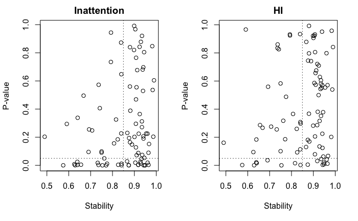

```r
abline(h=.05, lty=3)
abline(v=.85, lty=3)
```

```r
cor.test(1-pvals_inatt, meg_iqs, method='spearman')
```

```
    Spearman's rank correlation rho

data:  1 - pvals_inatt and meg_iqs
S = 142100, p-value = 0.1097
alternative hypothesis: true rho is not equal to 0
sample estimates:
       rho
-0.1697082
```

```r
cor.test(1-pvals_hi, meg_iqs, method='spearman')
```

```
    Spearman's rank correlation rho

data:  1 - pvals_hi and meg_iqs
S = 133650, p-value = 0.3471
alternative hypothesis: true rho is not equal to 0
sample estimates:
       rho
-0.1001358
```

Again, it doesn’t look like a more stable IC is more likely to be significantly correlated to SX.

# Theoretical component

This “augmented” ICA cannot be considered to be an unsupervised method. Regular ICAs, PCAs, or any other unsupervised dimensionality reduction methods do not take into consideration group membership or other possibly related variables. Here, we purposely used the augmented ICA method described in (Sripada REF) to tease out independent components that are also related to the total symptom count.

As stated in (Sripada REF), prior to the ICA analysis, the regression-based cleaning procedure of each individual connection (regression targets) involves using both the covariates of interest (i.e. inattention and HI symptoms) and nuisance covariates (i.e. sex, age, movement, movement squared) as predictors so that weak collinearities between effects of interest and nuisance effects do not result in removal of interesting signal. We then augment each (cleaned) connection by its mean effect for features of interest to induce selection of components related to these phenotypes of interest. Note here that we are effectively adding a constant for each connection, prior to running ICA.

We finally use nonparametric tests (corrected using Bonferroni) to tease out which stable components are independently related to inattention and HI symptoms. ICASSO (as illustrated above) shows no significant bias in attaching a higher stability metric to ICs more correlated to symptom counts. Also note that the majority of components (stable or not) show no relationship to the two phenotypes of interest.

# Correlation to total symptoms

But it so happens that we augmented the ICA with total symptoms, and not inattention or HI by itself. So, let’s see if the same analysis as above works for total symptoms.

```r
fmri_iqs = read.csv('~/data/fmri/fmri_iqs.csv', header = F)[,1]
library(RcppCNPy)
fmat <- npyLoad('/Users/sudregp/data/sripada/fmri/exp_scores_enrichedNoDummies1K.npy')
subjs = read.table('~/data/fmri/joel_all_147.txt')
exp_scores = cbind(subjs, fmat)
gf = read.csv('~/data/fmri/gf.csv')
df = merge(gf, exp_scores, by.x='maskid', by.y='V1')
df = df[df$used==1,]
total = df$inatt + df$hi
pvals = sapply(df[, 14:ncol(df)], function(d) cor.test(d, total, method='spearman', exact=F)$p.value)
adhdOnly = df$group!='NV'
total = df[adhdOnly,]$inatt + df[adhdOnly,]$hi
pvals_adhdOnly = sapply(df[adhdOnly, 14:ncol(df)], function(d) cor.test(d, total, method='spearman', exact=F)$p.value)
myorder = sort(fmri_iqs, index.return=T, decreasing = T)
par(mfrow=(c(1, 2)))
plot(fmri_iqs[myorder$ix], pvals[myorder$ix], xlab='Stability', ylab='P-value', main='Everyone')
abline(h=.05, lty=3)
```

```r
abline(v=.85, lty=3)
plot(fmri_iqs[myorder$ix], pvals_adhdOnly[myorder$ix], xlab='Stability', ylab='P-value', main='ADHD Only')
```

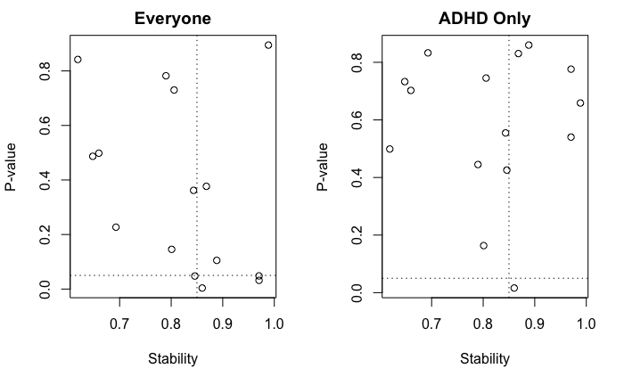

```r
abline(h=.05, lty=3)
abline(v=.85, lty=3)
```

```r
cor.test(1-pvals, fmri_iqs, method='spearman', alternative='greater')
```

```
    Spearman's rank correlation rho

data:  1 - pvals and fmri_iqs
S = 330, p-value = 0.06485
alternative hypothesis: true rho is greater than 0
sample estimates:
      rho
0.4107143
```

```r
cor.test(1-pvals_adhdOnly, fmri_iqs, method='spearman', alternative='greater')
```

```
    Spearman's rank correlation rho

data:  1 - pvals_adhdOnly and fmri_iqs
S = 638, p-value = 0.6943
alternative hypothesis: true rho is greater than 0
sample estimates:
       rho
-0.1392857
```

Still nothing for fMRI. Let’s check on MEG:

```r
bands = c('1-4', '4-8', '8-13', '13-30', '30-55', '65-100')
meg_iqs = c()
fmat = c()
for (b in bands) {
  meg_iqs = c(meg_iqs, read.csv(sprintf('~/data/meg/iqs_%s.csv', b), header = F)[,1])
  fmat = cbind(fmat, npyLoad(sprintf('/Users/sudregp/data/sripada/meg/exp_scores_%s_imcoh_enriched_1000perms_15ics.npy', b)))
}
subjs = read.table('~/data/meg/usable_subjects_5segs13p654_SAM.txt')
exp_scores = cbind(subjs, fmat)
gf = read.csv('~/data/meg/gf.csv')
df = merge(gf, exp_scores, by.x='maskid', by.y='V1')
df = df[df$used==1,]
total = df$inatt + df$hi
pvals = sapply(df[, 17:ncol(df)], function(d) cor.test(d, total, method='spearman', exact=F)$p.value)
adhdOnly = df$group!='NV'
total = df[adhdOnly,]$inatt + df[adhdOnly,]$hi
pvals_adhdOnly = sapply(df[adhdOnly, 17:ncol(df)], function(d) cor.test(d, total, method='spearman', exact=F)$p.value)
myorder = sort(meg_iqs, index.return=T, decreasing = T)
par(mfrow=(c(1, 2)))
plot(meg_iqs[myorder$ix], pvals[myorder$ix], xlab='Stability', ylab='P-value', main='All')
abline(h=.05, lty=3)
```

```r
abline(v=.85, lty=3)
plot(meg_iqs[myorder$ix], pvals_adhdOnly[myorder$ix], xlab='Stability', ylab='P-value', main='ADHD only')
```

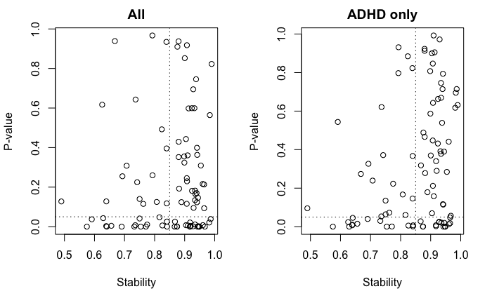

```r
abline(h=.05, lty=3)
abline(v=.85, lty=3)
```

```r
cor.test(1-pvals, meg_iqs, method='spearman', alternative='greater', exact=F)
```

```
    Spearman's rank correlation rho

data:  1 - pvals and meg_iqs
S = 129180, p-value = 0.7234
alternative hypothesis: true rho is greater than 0
sample estimates:
        rho
-0.06334115
```

```r
cor.test(1-pvals_adhdOnly, meg_iqs, method='spearman', alternative='greater', exact=F)
```

```
    Spearman's rank correlation rho

data:  1 - pvals_adhdOnly and meg_iqs
S = 145590, p-value = 0.9696
alternative hypothesis: true rho is greater than 0
sample estimates:
       rho
-0.1984525
```

# Number of ICs associated with symptoms

```r
fmri_iqs = read.csv('~/data/fmri/fmri_iqs.csv', header = F)[,1]
library(RcppCNPy)
fmat <- npyLoad('/Users/sudregp/data/sripada/fmri/exp_scores_enrichedNoDummies1K.npy')
subjs = read.table('~/data/fmri/joel_all_147.txt')
exp_scores = cbind(subjs, fmat)
gf = read.csv('~/data/fmri/gf.csv')
df = merge(gf, exp_scores, by.x='maskid', by.y='V1')
df = df[df$used==1,]
adhdOnly = df$group!='NV'
pvals_adhdOnly = sapply(df[adhdOnly, 14:ncol(df)], function(d) cor.test(d, df[adhdOnly,]$inatt, method='spearman', exact=F)$p.value)
print(sprintf('fMRI inatt: %d', sum(pvals_adhdOnly[fmri_iqs > .85] < .05/6)))
```

```
[1] "fMRI inatt: 1"
```

```r
pvals_adhdOnly = sapply(df[adhdOnly, 14:ncol(df)], function(d) cor.test(d, df[adhdOnly,]$hi, method='spearman', exact=F)$p.value)
print(sprintf('fMRI hi: %d', sum(pvals_adhdOnly[fmri_iqs > .85] < .05/6)))
```

```
[1] "fMRI hi: 0"
```

```r
total = df[adhdOnly,]$inatt + df[adhdOnly,]$hi
pvals_adhdOnly = sapply(df[adhdOnly, 14:ncol(df)], function(d) cor.test(d, total, method='spearman', exact=F)$p.value)
print(sprintf('fMRI total: %d', sum(pvals_adhdOnly[fmri_iqs > .85] < .05/6)))
```

```
[1] "fMRI total: 0"
```

```r
bands = c('1-4', '4-8', '8-13', '13-30', '30-55', '65-100')
meg_iqs = c()
fmat = c()
for (b in bands) {
  meg_iqs = c(meg_iqs, read.csv(sprintf('~/data/meg/iqs_%s.csv', b), header = F)[,1])
  fmat = cbind(fmat, npyLoad(sprintf('/Users/sudregp/data/sripada/meg/exp_scores_%s_imcoh_enriched_1000perms_15ics.npy', b)))
}
subjs = read.table('~/data/meg/usable_subjects_5segs13p654_SAM.txt')
exp_scores = cbind(subjs, fmat)
gf = read.csv('~/data/meg/gf.csv')
df = merge(gf, exp_scores, by.x='maskid', by.y='V1')
df = df[df$used==1,]
pvals_adhdOnly = sapply(df[adhdOnly, 17:ncol(df)], function(d) cor.test(d, df[adhdOnly,]$inatt, method='spearman', exact=F)$p.value)
print(sprintf('MEG inatt: %d', sum(pvals_adhdOnly[meg_iqs > .85] < .05/56)))
```

```
[1] "MEG inatt: 4"
```

```r
pvals_adhdOnly = sapply(df[adhdOnly, 17:ncol(df)], function(d) cor.test(d, df[adhdOnly,]$hi, method='spearman', exact=F)$p.value)
print(sprintf('MEG hi: %d', sum(pvals_adhdOnly[meg_iqs > .85] < .05/56)))
```

```
[1] "MEG hi: 5"
```

```r
total = df[adhdOnly,]$inatt + df[adhdOnly,]$hi
pvals_adhdOnly = sapply(df[adhdOnly, 17:ncol(df)], function(d) cor.test(d, total, method='spearman', exact=F)$p.value)
print(sprintf('MEG total: %d', sum(pvals_adhdOnly[meg_iqs > .85] < .05/56)))
```

```
[1] "MEG total: 5"
```

# 2 group association

We can also check whether there is a difference between stable and non-stable ICs in how they’re associated to different symptoms:

```r
fmri_iqs = read.csv('~/data/fmri/fmri_iqs.csv', header = F)[,1]
library(RcppCNPy)
fmat <- npyLoad('/Users/sudregp/data/sripada/fmri/exp_scores_enrichedNoDummies1K.npy')
subjs = read.table('~/data/fmri/joel_all_147.txt')
exp_scores = cbind(subjs, fmat)
gf = read.csv('~/data/fmri/gf.csv')
df = merge(gf, exp_scores, by.x='maskid', by.y='V1')
df = df[df$used==1,]
pvals = sapply(df[, 14:ncol(df)], function(d) cor.test(d, df$inatt, method='spearman', exact=F)$p.value)
adhdOnly = df$group!='NV'
pvals_adhdOnly = sapply(df[adhdOnly, 14:ncol(df)], function(d) cor.test(d, df[adhdOnly,]$inatt, method='spearman', exact=F)$p.value)
print('==== inatt ====')
```

```
[1] "==== inatt ===="
```

```r
wilcox.test(pvals[fmri_iqs<.85], pvals[fmri_iqs>=.85], alternative='greater')
```

```
    Wilcoxon rank sum test

data:  pvals[fmri_iqs < 0.85] and pvals[fmri_iqs >= 0.85]
W = 41, p-value = 0.05674
alternative hypothesis: true location shift is greater than 0
```

```r
print(sprintf('Medians: %.2f, %.2f', median(pvals[fmri_iqs<.85]), median(pvals[fmri_iqs>=.85])))
```

```
[1] "Medians: 0.64, 0.06"
```

```r
wilcox.test(pvals_adhdOnly[fmri_iqs<.85], pvals_adhdOnly[fmri_iqs>=.85], alternative='greater')
```

```
    Wilcoxon rank sum test

data:  pvals_adhdOnly[fmri_iqs < 0.85] and pvals_adhdOnly[fmri_iqs >= 0.85]
W = 28, p-value = 0.4773
alternative hypothesis: true location shift is greater than 0
```

```r
print(sprintf('Medians: %.2f, %.2f', median(pvals_adhdOnly[fmri_iqs<.85]), median(pvals_adhdOnly[fmri_iqs>=.85])))
```

```
[1] "Medians: 0.54, 0.53"
```

```r
pvals = sapply(df[, 14:ncol(df)], function(d) cor.test(d, df$hi, method='spearman', exact=F)$p.value)
adhdOnly = df$group!='NV'
pvals_adhdOnly = sapply(df[adhdOnly, 14:ncol(df)], function(d) cor.test(d, df[adhdOnly,]$hi, method='spearman', exact=F)$p.value)
print('==== hi ====')
```

```
[1] "==== hi ===="
```

```r
wilcox.test(pvals[fmri_iqs<.85], pvals[fmri_iqs>=.85], alternative='greater')
```

```
    Wilcoxon rank sum test

data:  pvals[fmri_iqs < 0.85] and pvals[fmri_iqs >= 0.85]
W = 31, p-value = 0.3445
alternative hypothesis: true location shift is greater than 0
```

```r
print(sprintf('Medians: %.2f, %.2f', median(pvals[fmri_iqs<.85]), median(pvals[fmri_iqs>=.85])))
```

```
[1] "Medians: 0.19, 0.24"
```

```r
wilcox.test(pvals_adhdOnly[fmri_iqs<.85], pvals_adhdOnly[fmri_iqs>=.85], alternative='greater')
```

```
    Wilcoxon rank sum test

data:  pvals_adhdOnly[fmri_iqs < 0.85] and pvals_adhdOnly[fmri_iqs >= 0.85]
W = 30, p-value = 0.3878
alternative hypothesis: true location shift is greater than 0
```

```r
print(sprintf('Medians: %.2f, %.2f', median(pvals_adhdOnly[fmri_iqs<.85]), median(pvals_adhdOnly[fmri_iqs>=.85])))
```

```
[1] "Medians: 0.47, 0.27"
```

```r
total = df$inatt + df$hi
pvals = sapply(df[, 14:ncol(df)], function(d) cor.test(d, total, method='spearman', exact=F)$p.value)
adhdOnly = df$group!='NV'
total = df[adhdOnly,]$inatt + df[adhdOnly,]$hi
pvals_adhdOnly = sapply(df[adhdOnly, 14:ncol(df)], function(d) cor.test(d, total, method='spearman', exact=F)$p.value)
print('==== total ====')
```

```
[1] "==== total ===="
```

```r
wilcox.test(pvals[fmri_iqs<.85], pvals[fmri_iqs>=.85], alternative='greater')
```

```
    Wilcoxon rank sum test

data:  pvals[fmri_iqs < 0.85] and pvals[fmri_iqs >= 0.85]
W = 39, p-value = 0.09051
alternative hypothesis: true location shift is greater than 0
```

```r
print(sprintf('Medians: %.2f, %.2f', median(pvals[fmri_iqs<.85]), median(pvals[fmri_iqs>=.85])))
```

```
[1] "Medians: 0.49, 0.08"
```

```r
wilcox.test(pvals_adhdOnly[fmri_iqs<.85], pvals_adhdOnly[fmri_iqs>=.85], alternative='greater')
```

```
    Wilcoxon rank sum test

data:  pvals_adhdOnly[fmri_iqs < 0.85] and pvals_adhdOnly[fmri_iqs >= 0.85]
W = 20, p-value = 0.8058
alternative hypothesis: true location shift is greater than 0
```

```r
print(sprintf('Medians: %.2f, %.2f', median(pvals_adhdOnly[fmri_iqs<.85]), median(pvals_adhdOnly[fmri_iqs>=.85])))
```

```
[1] "Medians: 0.55, 0.72"
```

And now for MEG:

```r
bands = c('1-4', '4-8', '8-13', '13-30', '30-55', '65-100')
meg_iqs = c()
fmat = c()
for (b in bands) {
  meg_iqs = c(meg_iqs, read.csv(sprintf('~/data/meg/iqs_%s.csv', b), header = F)[,1])
  fmat = cbind(fmat, npyLoad(sprintf('/Users/sudregp/data/sripada/meg/exp_scores_%s_imcoh_enriched_1000perms_15ics.npy', b)))
}
subjs = read.table('~/data/meg/usable_subjects_5segs13p654_SAM.txt')
exp_scores = cbind(subjs, fmat)
gf = read.csv('~/data/meg/gf.csv')
df = merge(gf, exp_scores, by.x='maskid', by.y='V1')
df = df[df$used==1,]
print('==== inatt ====')
```

```
[1] "==== inatt ===="
```

```r
pvals = sapply(df[, 17:ncol(df)], function(d) cor.test(d, df$inatt, method='spearman', exact=F)$p.value)
adhdOnly = df$group!='NV'
total = df[adhdOnly,]$inatt + df[adhdOnly,]$hi
pvals_adhdOnly = sapply(df[adhdOnly, 17:ncol(df)], function(d) cor.test(d, df[adhdOnly,]$inatt, method='spearman', exact=F)$p.value)
wilcox.test(pvals[meg_iqs<.85], pvals[meg_iqs>=.85], alternative='greater')
```

```
    Wilcoxon rank sum test with continuity correction

data:  pvals[meg_iqs < 0.85] and pvals[meg_iqs >= 0.85]
W = 849, p-value = 0.8055
alternative hypothesis: true location shift is greater than 0
```

```r
print(sprintf('Medians: %.2f, %.2f', median(pvals[meg_iqs<.85]), median(pvals[meg_iqs>=.85])))
```

```
[1] "Medians: 0.06, 0.14"
```

```r
wilcox.test(pvals_adhdOnly[meg_iqs<.85], pvals_adhdOnly[meg_iqs>=.85], alternative='greater')
```

```
    Wilcoxon rank sum test with continuity correction

data:  pvals_adhdOnly[meg_iqs < 0.85] and pvals_adhdOnly[meg_iqs >= 0.85]
W = 733, p-value = 0.9661
alternative hypothesis: true location shift is greater than 0
```

```r
print(sprintf('Medians: %.2f, %.2f', median(pvals_adhdOnly[meg_iqs<.85]), median(pvals_adhdOnly[meg_iqs>=.85])))
```

```
[1] "Medians: 0.10, 0.22"
```

```r
print('==== hi ====')
```

```
[1] "==== hi ===="
```

```r
pvals = sapply(df[, 17:ncol(df)], function(d) cor.test(d, df$hi, method='spearman', exact=F)$p.value)
adhdOnly = df$group!='NV'
total = df[adhdOnly,]$inatt + df[adhdOnly,]$hi
pvals_adhdOnly = sapply(df[adhdOnly, 17:ncol(df)], function(d) cor.test(d, df[adhdOnly,]$hi, method='spearman', exact=F)$p.value)
wilcox.test(pvals[meg_iqs<.85], pvals[meg_iqs>=.85], alternative='greater')
```

```
    Wilcoxon rank sum test with continuity correction

data:  pvals[meg_iqs < 0.85] and pvals[meg_iqs >= 0.85]
W = 841, p-value = 0.8233
alternative hypothesis: true location shift is greater than 0
```

```r
print(sprintf('Medians: %.2f, %.2f', median(pvals[meg_iqs<.85]), median(pvals[meg_iqs>=.85])))
```

```
[1] "Medians: 0.15, 0.21"
```

```r
wilcox.test(pvals_adhdOnly[meg_iqs<.85], pvals_adhdOnly[meg_iqs>=.85], alternative='greater')
```

```
    Wilcoxon rank sum test with continuity correction

data:  pvals_adhdOnly[meg_iqs < 0.85] and pvals_adhdOnly[meg_iqs >= 0.85]
W = 739, p-value = 0.9622
alternative hypothesis: true location shift is greater than 0
```

```r
print(sprintf('Medians: %.2f, %.2f', median(pvals_adhdOnly[meg_iqs<.85]), median(pvals_adhdOnly[meg_iqs>=.85])))
```

```
[1] "Medians: 0.26, 0.54"
```

```r
print('==== total ====')
```

```
[1] "==== total ===="
```

```r
total = df$inatt + df$hi
pvals = sapply(df[, 17:ncol(df)], function(d) cor.test(d, total, method='spearman', exact=F)$p.value)
adhdOnly = df$group!='NV'
total = df[adhdOnly,]$inatt + df[adhdOnly,]$hi
pvals_adhdOnly = sapply(df[adhdOnly, 17:ncol(df)], function(d) cor.test(d, total, method='spearman', exact=F)$p.value)
wilcox.test(pvals[meg_iqs<.85], pvals[meg_iqs>=.85], alternative='greater')
```

```
    Wilcoxon rank sum test with continuity correction

data:  pvals[meg_iqs < 0.85] and pvals[meg_iqs >= 0.85]
W = 842, p-value = 0.8211
alternative hypothesis: true location shift is greater than 0
```

```r
print(sprintf('Medians: %.2f, %.2f', median(pvals[meg_iqs<.85]), median(pvals[meg_iqs>=.85])))
```

```
[1] "Medians: 0.08, 0.17"
```

```r
wilcox.test(pvals_adhdOnly[meg_iqs<.85], pvals_adhdOnly[meg_iqs>=.85], alternative='greater')
```

```
    Wilcoxon rank sum test with continuity correction

data:  pvals_adhdOnly[meg_iqs < 0.85] and pvals_adhdOnly[meg_iqs >= 0.85]
W = 663, p-value = 0.992
alternative hypothesis: true location shift is greater than 0
```

```r
print(sprintf('Medians: %.2f, %.2f', median(pvals_adhdOnly[meg_iqs<.85]), median(pvals_adhdOnly[meg_iqs>=.85])))
```

```
[1] "Medians: 0.07, 0.37"
```

# Group based on association with total symptoms

```r
fmri_iqs = read.csv('~/data/fmri/fmri_iqs.csv', header = F)[,1]
library(RcppCNPy)
fmat <- npyLoad('/Users/sudregp/data/sripada/fmri/exp_scores_enrichedNoDummies1K.npy')
subjs = read.table('~/data/fmri/joel_all_147.txt')
exp_scores = cbind(subjs, fmat)
gf = read.csv('~/data/fmri/gf.csv')
df = merge(gf, exp_scores, by.x='maskid', by.y='V1')
df = df[df$used==1,]
# we need to combine MEG and fMRI, because we don't have enough components just in fMRI
adhdOnly = df$group!='NV'
total = df[adhdOnly,]$inatt + df[adhdOnly,]$hi
pvals_adhdOnly = sapply(df[adhdOnly, 14:ncol(df)], function(d) cor.test(d, total, method='spearman', exact=F)$p.value)
bands = c('1-4', '4-8', '8-13', '13-30', '30-55', '65-100')
meg_iqs = c()
fmat = c()
for (b in bands) {
  meg_iqs = c(meg_iqs, read.csv(sprintf('~/data/meg/iqs_%s.csv', b), header = F)[,1])
  fmat = cbind(fmat, npyLoad(sprintf('/Users/sudregp/data/sripada/meg/exp_scores_%s_imcoh_enriched_1000perms_15ics.npy', b)))
}
subjs = read.table('~/data/meg/usable_subjects_5segs13p654_SAM.txt')
exp_scores = cbind(subjs, fmat)
gf = read.csv('~/data/meg/gf.csv')
df = merge(gf, exp_scores, by.x='maskid', by.y='V1')
df = df[df$used==1,]
adhdOnly = df$group!='NV'
total = df[adhdOnly,]$inatt + df[adhdOnly,]$hi
pvalsMEG_adhdOnly = sapply(df[adhdOnly, 17:ncol(df)], function(d) cor.test(d, total, method='spearman', exact=F)$p.value)
# I'm not going to correct here because we correct based on stable components, which doesn't make sense here.
# pvals_idx = c(pvals_adhdOnly < .05/6, pvalsMEG_adhdOnly < .05/56)
pvals_idx = c(pvals_adhdOnly < .05, pvalsMEG_adhdOnly < .05)
pvals_idx = c(pvals_adhdOnly < .01, pvalsMEG_adhdOnly < .01)
sig = c(fmri_iqs, meg_iqs)[pvals_idx]
nonsig = c(fmri_iqs, meg_iqs)[!pvals_idx]
wilcox.test(sig, nonsig, alternative='greater')
```

```
    Wilcoxon rank sum test with continuity correction

data:  sig and nonsig
W = 561, p-value = 0.9116
alternative hypothesis: true location shift is greater than 0
```

```r
print(sprintf('Medians: %.2f, %.2f', median(sig), median(nonsig)))
```

```
[1] "Medians: 0.84, 0.89"
```